# Search Algorithms

## Part 6 - A Star

Recall our last solution via UCS. Apart from performing worse than DFS with more iterations, one might also have noticed something else. A cheaper alternative path!

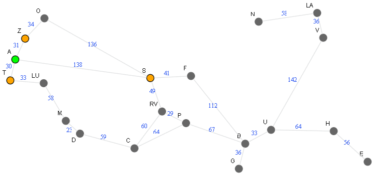

### Cost problem:

**Path chosen by UCS**: A - S - F - B => 138 + 41 + 112 = 291

**Alternate path**: A - S - RV - P - B => 138 + 49 + 29 + 67 = 283

We can make our algorithm to choose a cheaper path, by making better choice of nodes each time we choose one from the *bag*, the priority queue `openSet`

## Approach

Now we are clear the cost is the determining factor in choosing the next node. If we could add some sense to the gScore, about how we are faring in proceeding *towards* the goal, that could help to improve the choice. That is,

**new_cost = total_cost_from_start_to_that_node + a value representative of how we are faring towards the goal direction**

Since its addition, we could think, in terms of same unit, that is, distance itself. In a space, the shortest possible distance between two points, is the straight line distance (SLD) between them. Any path we are going to deduce, will have a cost, always greater to that.

When we are at any node, the shortest *virtual* straight line distance from that node to goal, could then always help us choose a better node.

Let us call it **heuristic** score hScore or h(n). Let the new cost be fScore or f(n). Then

**fScore = gScore + hScore**

If there are 3 neighbors to add to the queue, whichever neighbor having least sum of gScore and hScore, that is fScore could be our next best candidate. Why?

Least gScore tells us, that neighbor took least cost to arrive at that point among others. Least hScore tells us, that neighbor is *roughly possibly* nearer to the goal than others.

Since we are including only hScore for comparision w.r.t how distant they are from the goal for all nodes, and since that could be the minimum distance possible, we could be sure that, our comparision is fair for all nodes, in our scenario.

**Note:**

Remember, hScore is kinda approximation. And if costs include more factors, hScore could screw up also. SLD may not always be best hScore in all scenarios. Thus there are multiple ways to calculate hScore. Even SLD approach includes various methods like Euclidean, Manhattan etc. We stick with geodesic SLD for now.

It is also important, **hScore should not over estimate actual cost** as much as possible. Then, we might not be making a fair comparision between the fScores of nodes.

Heuristics is a deep subject by itself, so for now, we will move on with basics. There could never be an end to tuning an algorithm.

### Algorithm Development

Calculating cost is the primary change now. At every node, calculate a new total cost as below and store that in the queue/bag.

```
# f(n) = g(n) + h(n)
# g(n) = total actual SLD so far from 'start' to 'current neighbor'
# h(n) = SLD from current neighbor to 'goal'
```

**gScore**

In UCS, we used g(n) as below.

g(n) or gScore of each_neighbor = current_cost from start to current_node + distance(current_node, each_neighbor)

The current_cost was coming directly from queue, because that was what we stored for every node in first place. Now, we are going to store a different cost fScore or f(n) in the queue. So we would need a function to calculate the current_cost value.

We could use `cameFrom` to track back the nodes till start, and at every iteration, simply calculate the distance and sum up step costs to arrive at gScore. Thus this would be just amalgamation of `reconstructPath` and `distance` we already saw.

```python
from docHelpers_ipython import romania_location_map
import geopy
from math import floor

# TEST SETUP
M = romania_location_map
start = 'A'
cameFrom = {}
cameFrom[start] = None
for each_parent in M.keys():
    for each_child in M[each_parent]['connections']:
        cameFrom[each_child] = each_parent

def distance(start_node, end_node):

    (x0,y0) = M[start_node]['pos']
    (x1,y1) = M[end_node]['pos']
    return floor(geopy.distance.geodesic((y0,x0), (y1,x1)).miles)

# NEEDED FUNCTION TO CALCULATE DISTANCE FROM CURRENT NODE BACK TO START
def totalDistance(current_node):
    cost = 0
    while current_node is not None:
        parent = cameFrom.get(current_node, None)
        if parent is not None:
            cost += distance(current_node, parent)
        current_node = parent
    return cost

print(totalDistance('F'))  # 138 + 41 = 179
print(totalDistance('C'))  # 138 + 49 + 29 + 64 = 280
```

```
179
280
```

You might have manually arrived at a different value for 'C'. Note 'C' could be arrived at via multiple routes due to cycles in the graph and our function calculated just how cameFrom was constructed in test setup just above, which in turn depends on how our map description M was.

This is an important insight. In our algorithm, this later would make an improvisation. But for now, remember, `cameFrom` in our algorithm depends on how nodes were traversed, and thus `totalDistance` depends on that. That is ok for now to proceed.

**hScore**

This heuristic score, so as to have same 'weightage' as the gScore, it would be summed up with, shall also be a virtual SLD from neighbor to the goal for reasons we discussed earlier. So programmatically it is simply calling distance function with both nodes (neighbor and goal)

**Start**

Let us initialize as usual..same as UCS here..

```
openSet = { (0,'A') }
closedSet = ( 'A' )
cameFrom[ 'A' ] = None
```

Coding..

```python
from queue import PriorityQueue
from docHelpers_ipython import romania_location_map

cameFrom = { }
openSet = PriorityQueue()
M = romania_location_map
start = 'A'
goal = 'B'

openSet.put((0,start))
closedSet = set(start)
cameFrom[start] = None
```

**ITERATION 1**

```
Is openSet empty? No. So Go on.
Take least cost path from openSet
{(0, 'A')} : (0, 'A')
Current node: 'A'. Kids: 'S','T','Z'
Is 'A' the goal? No. So Go on.

                        closedSet : ( 'A' )


'A' to 'S':

            past cost from 'A' to 'S' : 138

       heuristic cost from 'S' to 'B' : 135

                                total : 273

                            closedSet : ( 'A', 'S' )
'A' to 'T':

            past cost from 'A' to 'T' : 30

       heuristic cost from 'T' to 'B' : 256

                                total : 286

                            closedSet : ( 'A', 'S', 'T' )

'A' to 'Z':

            past cost from 'A' to 'Z' : 31

       heuristic cost from 'Z' to 'B' : 269

                                total : 300

                            closedSet : ( 'A', 'S', 'T', 'Z' )
Result: openSet = { (273,'S'), (286,'T'), (300,'Z') }
</pre>
```

```python
if not openSet.empty():   # Note unike deque, we check differently using empty() if our bag is empty or not

    current_cost, current_node = openSet.get()   # Note, we 'get()' now and it returns a 'set', a tuple

    if current_node is not goal:

        all_neighbors = M.get(current_node,[]).get('connections',[])
        for each_neighbor in all_neighbors:   # each neighbor is a 'set' having a cost and node itself
            if each_neighbor not in closedSet:

                #NOTE: fScore = gScore + hScore
                gScore = totalDistance(current_node) + distance(current_node,each_neighbor)
                hScore = distance(each_neighbor, goal)
                fScore = gScore + hScore

                openSet.put((fScore, each_neighbor))
                cameFrom[each_neighbor] = current_node
                closedSet.add(each_neighbor)

print(list(openSet.queue))
print(list(closedSet))
```

```
[(273, 'S'), (286, 'T'), (300, 'Z')]
['S', 'T', 'A', 'Z']
```

Visualizing..(do not bother about order of added nodes)

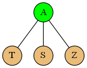

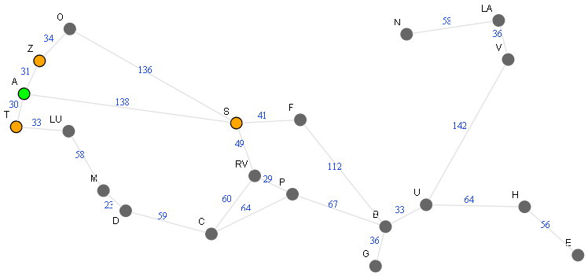

```python
from docHelpers_ipython import Doc
from IPython.core.display import HTML

doc = Doc(M)

resultHTML = doc.computeGraphs('A',['T','S','Z'], mappy=True, tree=True, queue=True, HTML=True)
HTML(resultHTML)
```

**ITERATION 2**

```
Is openSet empty? No. So Go on.
Take least cost path from openSet
{ (273,'S'), (286,'T'), (300,'Z')** } : (273,'S')
Current node: 'S'. Kids: 'F', 'RV', 'O'

Is 'S' the goal? No. So Go on.

                        closedSet : ( 'A', 'S', 'T', 'Z' )


'S' to 'F':

            past cost from 'A' to 'F' : 138+41

       heuristic cost from 'F' to 'B' : 112

                                total : 291
                            closedSet : ( 'A', 'S', 'T', 'Z' ,'F' )

'S' to 'RV':

           past cost from 'A' to 'RV' : 138+49

      heuristic cost from 'RV' to 'B' : 97

                                total : 284

                            closedSet : ( 'A', 'S', 'T', 'Z', 'F', 'RV' )

'S' to 'O':

            past cost from 'A' to 'O' : 138+136

       heuristic cost from 'O' to 'B' : 271

                                total : 545

                            closedSet : ( 'A', 'S', 'T', 'Z', 'F', 'RV', 'O' )
Result: openSet = { (286,'T'), (300,'Z'), (291,'F'), (284,'RV'), (545,'O') }
</pre>
```

```python
if not openSet.empty():   # Note unike deque, we check differently using empty() if our bag is empty or not

    current_cost, current_node = openSet.get()   # Note, we 'get()' now and it returns a 'set', a tuple

    if current_node is not goal:

        all_neighbors = M.get(current_node,[]).get('connections',[])
        for each_neighbor in all_neighbors:   # each neighbor is a 'set' having a cost and node itself
            if each_neighbor not in closedSet:

                #NOTE: fScore = gScore + hScore
                gScore = totalDistance(current_node) + distance(current_node,each_neighbor)
                hScore = distance(each_neighbor, goal)
                fScore = gScore + hScore

                openSet.put((fScore, each_neighbor))
                cameFrom[each_neighbor] = current_node
                closedSet.add(each_neighbor)

print(list(openSet.queue))
print(list(closedSet))
```

```
[(284, 'RV'), (286, 'T'), (291, 'F'), (300, 'Z'), (545, 'O')]
['F', 'O', 'Z', 'RV', 'S', 'T', 'A']
```

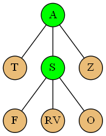

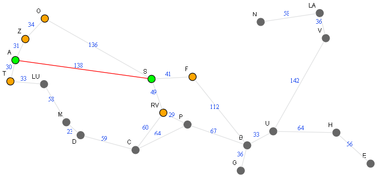

```python
resultHTML = doc.computeGraphs('S',['F','RV','O'], mappy=True, tree=True, queue=True, HTML=True)
HTML(resultHTML)
```

**ITERATION 3**

[output not shown]

```python
if not openSet.empty():   # Note unike deque, we check differently using empty() if our bag is empty or not

    current_cost, current_node = openSet.get()   # Note, we 'get()' now and it returns a 'set', a tuple

    if current_node is not goal:

        all_neighbors = M.get(current_node,[]).get('connections',[])
        for each_neighbor in all_neighbors:   # each neighbor is a 'set' having a cost and node itself
            if each_neighbor not in closedSet:

                #NOTE: fScore = gScore + hScore
                gScore = totalDistance(current_node) + distance(current_node,each_neighbor)
                hScore = distance(each_neighbor, goal)
                fScore = gScore + hScore

                openSet.put((fScore, each_neighbor))
                cameFrom[each_neighbor] = current_node
                closedSet.add(each_neighbor)

print(list(openSet.queue))
print(list(closedSet))
```

```
[(283, 'P'), (300, 'Z'), (286, 'T'), (545, 'O'), (361, 'C'), (291, 'F')]
['F', 'C', 'P', 'O', 'Z', 'RV', 'S', 'T', 'A']
```

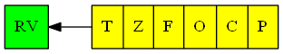

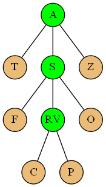

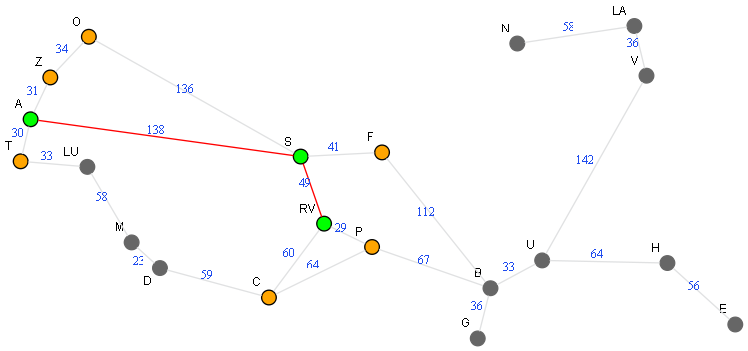

```python
resultHTML = doc.computeGraphs('RV',['C','P'], mappy=True, tree=True, queue=True, HTML=True)
HTML(resultHTML)
```

**ITERATION 4**

[output not shown]

```python
if not openSet.empty():   # Note unike deque, we check differently using empty() if our bag is empty or not

    current_cost, current_node = openSet.get()   # Note, we 'get()' now and it returns a 'set', a tuple

    if current_node is not goal:

        all_neighbors = M.get(current_node,[]).get('connections',[])
        for each_neighbor in all_neighbors:   # each neighbor is a 'set' having a cost and node itself
            if each_neighbor not in closedSet:

                #NOTE: fScore = gScore + hScore
                gScore = totalDistance(current_node) + distance(current_node,each_neighbor)
                hScore = distance(each_neighbor, goal)
                fScore = gScore + hScore

                openSet.put((fScore, each_neighbor))
                cameFrom[each_neighbor] = current_node
                closedSet.add(each_neighbor)

print(list(openSet.queue))
print(list(closedSet))
```

```
[(283, 'B'), (300, 'Z'), (286, 'T'), (545, 'O'), (361, 'C'), (291, 'F')]
['F', 'C', 'P', 'O', 'Z', 'B', 'RV', 'S', 'T', 'A']
```

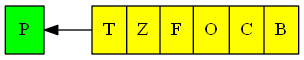

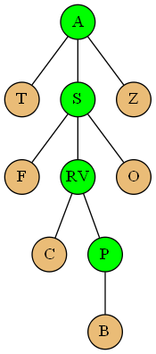

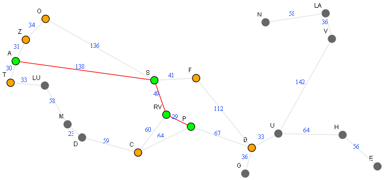

```python
resultHTML = doc.computeGraphs('P',['B'], mappy=True, tree=True, queue=True, HTML=True)
HTML(resultHTML)
```

**ITERATION 5**

```
Is openSet empty? No. So Go on.
Take least cost path from openSet
{ (286,'T'), (300,'Z'), (291,'F'), (545,'O'), (361,'C'), (283,'B') } : (283,'B')
Current node: 'B'. Kids: 'G', 'U'
**Is 'B' the goal? YES. So return.**
```

```python
if not openSet.empty():   # Note unike deque, we check differently using empty() if our bag is empty or not

    current_cost, current_node = openSet.get()   # Note, we 'get()' now and it returns a 'set', a tuple

    if current_node is goal:
        print('Yes. Success. Current node: ', current_node)

    if current_node is not goal:

        all_neighbors = M.get(current_node,[]).get('connections',[])
        for each_neighbor in all_neighbors:   # each neighbor is a 'set' having a cost and node itself
            if each_neighbor not in closedSet:

                #NOTE: fScore = gScore + hScore
                gScore = totalDistance(current_node) + distance(current_node,each_neighbor)
                hScore = distance(each_neighbor, goal)
                fScore = gScore + hScore

                openSet.put((fScore, each_neighbor))
                cameFrom[each_neighbor] = current_node
                closedSet.add(each_neighbor)

print(list(openSet.queue))
print(list(closedSet))
```

```
Yes. Success. Current node:  B
[(286, 'T'), (300, 'Z'), (291, 'F'), (545, 'O'), (361, 'C')]
['F', 'C', 'P', 'O', 'Z', 'B', 'RV', 'S', 'T', 'A']
```

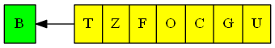

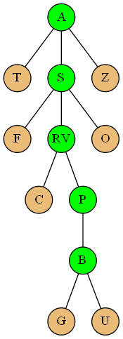

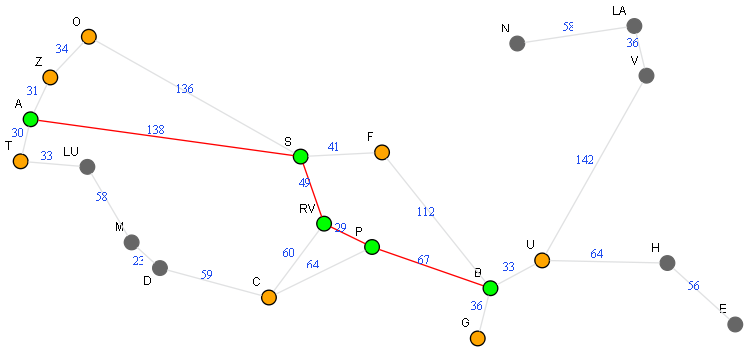

```python
resultHTML = doc.computeGraphs('B',['G','U'], mappy=True, tree=True, queue=True, HTML=True)
HTML(resultHTML)
```

Done :) We not only found the route, we found the **cheapest** route from 'A' to 'B'

[figure not shown]

Let us modularize as a proper function like BFS/DFS/UCS and check again..

```python
from queue import PriorityQueue
from docHelpers_ipython import romania_location_map
from math import floor
import geopy

cameFrom = { }

# NEEDED FUNCTION TO CALCULATE DISTANCE FROM CURRENT NODE BACK TO START
def totalDistance(current_node):
    cost = 0
    while current_node is not None:
        parent = cameFrom.get(current_node, None)
        if parent is not None:
            cost += distance(current_node, parent)
        current_node = parent
    return cost

def distance(start_node, end_node):

    (x0,y0) = M[start_node]['pos']
    (x1,y1) = M[end_node]['pos']
    return floor(geopy.distance.geodesic((y0,x0), (y1,x1)).miles)

def reconstructPath(current_node):
    Path = [current_node]
    while current_node is not None:
        current_node = cameFrom[current_node]
        Path.append(current_node)
    return reversed(Path[:-1])

def AStar(start, goal):

    # INITIALIZATION
    openSet = PriorityQueue()
    openSet.put((0,start))
    closedSet = set(start)
    cameFrom[start] = None

    # MAIN LOOP
    while not openSet.empty():

        current_cost, current_node = openSet.get()

        if current_node is goal:
            print('Success. Route from {} to {} found. Cost: {} Path: {}'.format(start,goal,current_cost,list(reconstructPath(current_node))))
            break

        all_neighbors = M.get(current_node,[]).get('connections',[])
        for each_neighbor in all_neighbors:
            if each_neighbor not in closedSet:

                #gScore = 'cost till current_node' + 'cost between current node and its neighbor'
                gScore = totalDistance(current_node) + distance(current_node,each_neighbor)
                hScore = distance(each_neighbor, goal)
                fScore = gScore + hScore

                openSet.put((fScore, each_neighbor))
                cameFrom[each_neighbor] = current_node
                closedSet.add(each_neighbor)

        #print(openSet.queue)  #just to verify


    return 'No Goal found!'


M = romania_location_map
start = 'A'
goal = 'B'
result = AStar(start, goal)
```

```
Success. Route from A to B found. Cost: 283 Path: ['A', 'S', 'RV', 'P', 'B']
```

## Visualization (Optional)

We will inject a small code to keep track of bag contents, nodes traversed for sake of visualization. And then render an animation to visualize how nodes were traversed to reach the goal.

```
Success. Route from A to B found. Cost: 283 Path: ['A', 'S', 'RV', 'P', 'B']
```

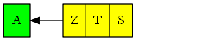

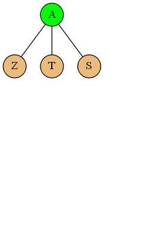

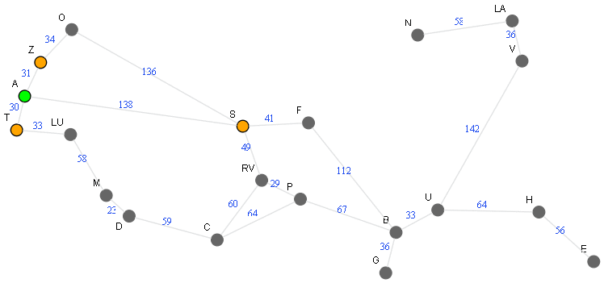

```python
from queue import PriorityQueue
from docHelpers_ipython import romania_location_map
from math import floor
import geopy

# VISUALIZATION PURPOSE
from docHelpers_ipython import Doc
from IPython.display import display, Image

cameFrom = { }

# NEEDED FUNCTION TO CALCULATE DISTANCE FROM CURRENT NODE BACK TO START
def totalDistance(current_node):
    cost = 0
    while current_node is not None:
        parent = cameFrom.get(current_node, None)
        if parent is not None:
            cost += distance(current_node, parent)
        current_node = parent
    return cost

def distance(start_node, end_node):

    (x0,y0) = M[start_node]['pos']
    (x1,y1) = M[end_node]['pos']
    return floor(geopy.distance.geodesic((y0,x0), (y1,x1)).miles)

def reconstructPath(current_node):
    Path = [current_node]
    while current_node is not None:
        current_node = cameFrom[current_node]
        Path.append(current_node)
    return reversed(Path[:-1])

def AStar(start, goal):

    # INITIALIZATION
    openSet = PriorityQueue()
    openSet.put((0,start))
    closedSet = set(start)
    cameFrom[start] = None

    # MAIN LOOP
    while not openSet.empty():

        current_cost, current_node = openSet.get()

        if current_node is goal:
            print('Success. Route from {} to {} found. Cost: {} Path: {}'.format(start,goal,current_cost,list(reconstructPath(current_node))))
            break

        # VISUALIZATION PURPOSE
        all_neighbors = reversed(M.get(current_node,[]).get('connections',[]))
        considered_neighbors = list(set(all_neighbors) - set(closedSet)) # thank you: https://stackoverflow.com/questions/3462143/get-difference-between-two-lists

        all_neighbors = M.get(current_node,[]).get('connections',[])
        for each_neighbor in all_neighbors:
            if each_neighbor not in closedSet:

                #gScore = 'cost till current_node' + 'cost between current node and its neighbor'
                gScore = totalDistance(current_node) + distance(current_node,each_neighbor)
                hScore = distance(each_neighbor, goal)
                fScore = gScore + hScore

                openSet.put((fScore, each_neighbor))
                cameFrom[each_neighbor] = current_node
                closedSet.add(each_neighbor)

        # VISUALIZATION PURPOSE
        _ = doc.computeGraphs(current_node, considered_neighbors)

        #print(openSet.queue)  #just to verify

    # VISUALIZATION PURPOSE
    _ = doc.computeGraphs(current_node, [])
    return 'No Goal found!'


M = romania_location_map
start = 'A'
goal = 'B'

# VISUALIZATION PURPOSE - called here caz we use doc in ourSearchAlgo
doc = Doc(M)

result = AStar(start, goal)

# VISUALIZATION PURPOSE
images = doc.render()
display(Image(images[0]),Image(images[1]),Image(images[2]))
```

Ha Ha, Isnt that awesome? Algorithm is traversing towards goal, as if it already knows the path, and still ends up with the cheapest path.

### UCS vs AStar Visual Comparison:

Take a moment to compare the UCS and Astar, we just finished.

[figure not shown]

### That's it?

There is still a small trap ahead. Try from 'A' to 'U' (over to next section for solving this). You will not get cheapest path

[figure not shown]